# Visualizations for the Fundamentals of Data Visualization (gdv) Module

Joel Grosjean

R-Version: **[Default] [64-bit] C:\Program Files\R\R-4.0.2**

The Data is from the Cross-selling in Banking Challenge.

#### installation and loading of packages

```r
packages <- c("tidyverse", "data.table", "lubridate", "ggplot2", "ggthemes", "svglite", "sf", "patchwork")

# Install all the required packages if not yet installed
installed_packages <- packages %in% rownames(installed.packages())

if (any(installed_packages == FALSE)) {
  install.packages(packages[!installed_packages])
}

# load the packages
invisible(lapply(packages, library, character.only = TRUE))

# set to TRUE to see all summaries in notebook
summaries = FALSE
```

#### importing the data

```r
disposition <- read.csv2("csv_Dateien/disp.csv")
client <- read.csv2("csv_Dateien/client.csv")
account <- read.csv2("csv_Dateien/account.csv")
card <- read.csv2("csv_Dateien/card.csv")
loan <- read.csv2("csv_Dateien/loan.csv")
transaction <- read.csv2("csv_Dateien/trans.csv")
perm_order <- read.csv2("csv_Dateien/order.csv")
district <- read.csv2("csv_Dateien/district.csv")
```

## data wrangling

#### renaming columns with duplicate names to prevent confusion

```r
disposition <- disposition %>% rename(client_type = type)

client <- client %>% rename(client_district_id = district_id)

account <- account %>%
  rename(
    acc_district_id = district_id,
    acc_creation_date = date
  )

card <- card %>%
  rename(
    card_creation_date = issued,
    card_type = type
  )

loan <- loan %>%
  rename(
    loan_creation_date = date,
    loan_amount = amount,
    loan_payments = payments,
    loan_duration = duration,
    loan_status = status
  )

transaction <- transaction %>%
  rename(
    trans_date = date,
    trans_type = type,
    trans_amount = amount,
    acc_balance = balance,
    bank_to = bank,
    account_to = account
  )

perm_order <- perm_order %>% rename(order_amount = amount)

district <- district %>%
  rename(
    district_id = A1,
    district_name = A2,
    region = A3,
    inhabitants = A4,
    mun_less500 = A5, # number of municipalities with less than 500 inhabitants
    mun_to2000 = A6, # number of municipalities with 500 - 2000 inhabitants
    mun_to10000 = A7, # number of municipalities with 2000 - 10000 inhabitants
    mun_over10000 = A8, # number of municipalities with more than 10000 inhabitants
    num_cities = A9,
    ratio_urban_pop = A10,
    average_salary = A11,
    unemployed_95 = A12, # unemployment in 1995
    unemployed_96 = A13, # unemployment in 1996
    enterpreneurs_per_1000 = A14,
    crimes_95 = A15, # number of crimes in 1995
    crimes_96 = A16 # number of crimes in 1996
  )
```

#### translating czech to english

```r
account <- account %>%
  mutate(frequency = case_when(
    frequency == "POPLATEK MESICNE" ~ "monthly",
    frequency == "POPLATEK TYDNE" ~ "weekly",
    frequency == "POPLATEK PO OBRATU" ~ "after transaction",
    is.na(frequency) ~ "unknown")
  )

transaction <- transaction %>%
  mutate(k_symbol = case_when(
    k_symbol == "POJISTNE" ~ "Payment insurance",
    k_symbol == "SLUZBY" ~ "Payment statement",
    k_symbol == "UROK" ~ "Payment interest",
    k_symbol == "SANKC. UROK" ~ "Payment overdraft interest",
    k_symbol == "SIPO" ~ "Payment household",
    k_symbol == "DUCHOD" ~ "Payment old-age pension",
    k_symbol == "UVER" ~ "Payment loan")
  )

perm_order <- perm_order %>%
  mutate(k_symbol = case_when(
    k_symbol == "POJISTNE" ~ "Payment insurance",
    k_symbol == "SIPO" ~ "Payment household",
    k_symbol == "LEASING" ~ "Payment leasing",
    k_symbol == "UVER" ~ "Payment loan")
  )

transaction <- transaction %>%
  mutate(trans_type = case_when(
    trans_type == "PRIJEM" ~ "income",
    trans_type == "VYDAJ" ~ "expenses")
  )

transaction <- transaction %>%
  mutate(operation = case_when(
    operation == "VYBER KARTOU" ~ "Credit card withdrawal",
    operation == "VKLAD" ~ "Credit in cash",
    operation == "PREVOD Z UCTU" ~ "Collection from another bank",
    operation == "VYBER" ~ "Cash withdrawal",
    operation == "PREVOD NA UCET" ~ "Remittance to another bank")
  )
```

#### transforming variables

```r
# detaching information about sex from birthday
client <- client %>%
  mutate(sex = case_when(
    grepl(pattern = "\\d{2}[5-8]\\d{3}", client$birth_number) ~ "female",
    grepl(pattern = "\\d{2}[0-4]\\d{3}", client$birth_number) ~ "male",
    is.na(birth_number) ~ "unknown")
  )

# formatting birthday as a correct date without information about sex
client <- client %>%
  mutate(
    birth_number = as.double(birth_number),
    birth_number = case_when(sex == "female" ~ birth_number - 5000, sex == "male" ~ birth_number),
    birth_number = as.character(birth_number),
    birth_number = paste("19", birth_number, sep = ""),
    birth_number = as.Date(as.character(birth_number), format = "%Y%m%d")
  )

# formatting date as date in other tables
card <- card %>%
  separate(col = card_creation_date, into = c("card_creation_date", "time"), sep = " ") %>%
  select(1:4)

account$acc_creation_date <- as.Date(as.character(account$acc_creation_date), format ="%y%m%d")
card$card_creation_date <- as.Date(as.character(card$card_creation_date), format = "%y%m%d")
loan$loan_creation_date <- as.Date(as.character(loan$loan_creation_date), format = "%y%m%d")
transaction$trans_date <- as.Date(as.character(transaction$trans_date), format = "%y%m%d")
transaction <- transaction %>% mutate(trans_period = format(trans_date, "%Y %m"))

# formatting numberical variables as double
loan$loan_payments <- as.double(as.character(loan$loan_payments))
perm_order$order_amount <- as.double(as.character(perm_order$order_amount))
transaction$trans_amount <- as.double(as.character(transaction$trans_amount))
transaction$acc_balance <- as.double(as.character(transaction$acc_balance))
district$ratio_urban_pop <- as.double(as.character(district$ratio_urban_pop))
district$unemployed_95 <- as.double(as.character(district$unemployed_95))
district$unemployed_96 <- as.double(as.character(district$unemployed_96))
district$crimes_95 <- as.double(as.character(district$crimes_95))
```

#### cleaning missing data

```r
# imputing median for missing values in district data
district <- district %>%
  mutate(
    crimes_95 = ifelse(is.na(crimes_95), median(crimes_95, na.rm = T), crimes_95),
    unemployed_95 = ifelse(is.na(unemployed_95), median(unemployed_95, na.rm = T), unemployed_95)
  )

# cleaning missing data in transaction table
# all observations with a missing transaction type have the operation 'cash_withdrawal', which means that the transaction type is 'withdrawal'.
transaction <- transaction %>%
  mutate(trans_type = case_when(trans_type != is.na(trans_type) ~ trans_type, is.na(trans_type) ~ "expenses"))

# all observations where the operation is missing have the 'k_symbol' 'Payment interest', which means that the operation is also 'Payment Interest'.
transaction <- transaction %>%
  mutate(operation = case_when(operation != is.na(operation) ~ operation, is.na(operation) ~ "Payment interest"))
```

The tables perm_order (permanent orders), transaction and district had missing values. For the district table, we were able to simply replace the two missing values with the median. For the transaction table, we were able to fix the missing values in two columns. However, for the k_symbol and account_to and bank_to columns, we did not have enough information to do so. In the permanent order table, there were missing values only in the k_symbol column. But we could not replace these either

#### calculating month-end

```r
transaction_monthly <- transaction %>%
  select(account_id:trans_type, trans_amount:acc_balance) %>% # selecting the required columns
  mutate(trans_amount = case_when(
    trans_type == "expenses" ~ trans_amount * -1, # making expenses negative
    trans_type == "income" ~ trans_amount)
  ) %>%
  arrange(account_id, trans_date) %>%
  mutate(month = format(trans_date, "%m"), year = format(trans_date, "%Y")) %>%
  group_by(month, year, account_id, trans_type) %>% # grouping to create income and expenses for ever month
  mutate(balance_change = sum(trans_amount, na.rm = T)) %>%
  distinct(account_id, year, month, balance_change, trans_type) %>%
  arrange(account_id, year, month, trans_type) %>%
  ungroup() %>%
  pivot_wider(names_from = trans_type, values_from = balance_change) %>% # pivoting to have expenses and income in same row
  mutate(
    balance_change = if_else(is.na(income),0,income) + if_else(is.na(expenses),0,expenses), # creating column for change in balance
    date = as.Date(paste(year,month,01,sep = "-"),format = "%Y-%m-%d") # creating date for moth-end statement
  )

# joining transaction table with itself to calculate balance
transaction_monthly <- inner_join(
  transaction_monthly,transaction_monthly,by = 'account_id')


transaction_monthly <- transaction_monthly %>%
  mutate(balance_change.y = ifelse(date.y > date.x, 0, balance_change.y)) %>%
  group_by(account_id,date.x,income.x,expenses.x,balance_change.x, month.x, year.x) %>%
  summarise(balance = sum(balance_change.y, na.rm = T)) %>%  # calculating balance
  ungroup() %>%
  rename(
    date = date.x,
    expenses = expenses.x,
    income = income.x,
    balance_change = balance_change.x,
    month = month.x,
    year = year.x
  ) %>%
  complete(date = seq.Date(min(date), max(date), by="month"), account_id) %>%
  group_by(account_id) %>%
  fill('balance') %>% # creating month-end statements for months without transactions
  drop_na(balance) %>%
  mutate(
    income = ifelse(is.na(income), 0, income), # replacing NA's with zeros
    expenses = ifelse(is.na(expenses), 0, expenses),
    balance_change = ifelse(is.na(balance_change), 0, balance_change)
  )

transaction_monthly <- transaction_monthly %>%
  mutate(date = date %m+% months(1), date = date -1)
```

We recalculated the balance because it wasn’t always correct before. This is because we didn’t know which was the last transaction of the month.

#### simplifying district data

```r
district <- district %>%
  mutate(avg_crime_rate_per_1000 = round(((crimes_95 + crimes_96) / 2) / inhabitants *1000),
         avg_unemployment = (unemployed_95 + unemployed_96) / 2) %>%
  select(c(-(mun_less500:num_cities),-(average_salary:unemployed_96),-(crimes_95:crimes_96)))
```

Here we have calculated the average crime rate per 1000 inhabitants and the average unemployment rate in percent. We have combined the two years for which we have data. On the one hand, this makes the values more robust, and on the other hand, it reduces the amount of analysis needed. We have removed the variables for the number of municipalities within a size range, as we didn’t expect any findings from this that we couldn’t find with the proportion of the urban population.

#### joining the tables

```r
# creating db_base by joining `disposition` and `client`
db_base <- disposition %>%
  left_join(
    x = disposition,
    y = client,
    by = "client_id"
  ) %>%
  select(account_id:sex)

# using pivot_wider() to bring table into a wide format by separating owner and disponent into separate columns
db_base <- pivot_wider(
  db_base,
  names_from = client_type,
  values_from = c(birth_number, client_district_id, sex))

# joining `account` and `loan` with `db_base`
db_base <- db_base %>%
  left_join(
    x = .,
    y = account,
    by = "account_id"
  ) %>%
  left_join(
    x = .,
    y = loan,
    by = "account_id"
  )

# creating a table for account owners
disposition_owners <- disposition %>%
  filter(client_type == "OWNER") %>%
  select(disp_id, account_id)

# joining 'disposition_owners' and `card` with `db_base`
db_base <- db_base %>%
  left_join(
    x = .,
    y = disposition_owners,
    by = "account_id"
  ) %>%
  left_join(
    x = .,
    y = card,
    by = "disp_id"
  )

# adding the column `number_of_perm_orders` to the table `perm_order`
perm_order <- perm_order %>%
  group_by(account_id) %>%
  summarise(number_of_perm_orders = n()) %>%
  ungroup()

# joining `perm_order` with `db_base`
db_base <- db_base %>%
  left_join(
    x = .,
    y = perm_order,
    by = 'account_id'
  )

# removing district_id of disponents and accounts to simplify the analysis
db_base <- db_base %>%
  rename(district_id = client_district_id_OWNER) %>%
  select(-client_district_id_DISPONENT,-acc_district_id)

# joining `district` with `db_base`
db_base <- db_base %>%
  left_join(
    x = .,
    y = district,
    by = "district_id"
  )

# joining `transaction_monthly with `db_base`
db_base <- db_base %>%
  right_join(
    x = .,
    y = transaction_monthly,
    by = "account_id") %>%
  select(- c(month ,year))

# change data type to 'factor' if the data type is `character`
db_base <- mutate_if(db_base, is.character, as.factor)

# removing all unnecessary tables
remove(disposition_owners, transaction_monthly)

# show summary of table if "summaries" equals "TRUE"
if (summaries) {
  summary(db_base)
}

# saving work space
save.image(file = "work_space.RData")
```

#### loading work space

```r
load("work_space.RData")
```

## credit card

#### creating a data set with all transactions

```r
db_card_longer <- db_base %>%
  select(c(-loan_id,-(loan_amount:loan_payments))) %>% # removing all unnecessary credit information
  mutate(
    time_until_card = as.double(difftime(date, card_creation_date, unit = "days")) / 365.25, # time between observation and card purchase
    age_card_purchase = lubridate::year(card_creation_date) - lubridate::year(birth_number_OWNER),
    month_card_purchase = lubridate::month(card_creation_date) - lubridate::month(birth_number_OWNER),
    age_card_purchase = ifelse(
      test = is.na(age_card_purchase),
      yes = lubridate::year(as.Date("1998-01-06")) - lubridate::year(birth_number_OWNER), # if no card is bought, use median date of purchase
      no =  age_card_purchase),
    month_card_purchase = ifelse(
      test = is.na(month_card_purchase),
      yes = lubridate::month(as.Date("1998-01-06")) - lubridate::month(birth_number_OWNER), # doing the same for month
      no =  month_card_purchase),
    age_card_purchase = ifelse(month_card_purchase < 0, age_card_purchase - 1, age_card_purchase) # correcting age with info about month
  ) %>%
  select(-(month_card_purchase)) %>% # removing auxiliary variable
  mutate(
    loan_status_cat = case_when(
      loan_status == 'A' ~ 'b. no problems', loan_status == 'C' ~ 'b. no problems', # categorizing loan status
      loan_status == 'B' ~ 'a. problems', loan_status == 'D' ~ 'a. problems'),
    loan_status_cat = as.factor(loan_status_cat),
    perm_orders = case_when(
      number_of_perm_orders >= 1 ~ 'b. uses permanent orders', # categorize permanent orders
      is.na(number_of_perm_orders) ~ 'a. uses no permanent orders'),
    number_of_perm_orders = as.factor(number_of_perm_orders))

# creating a data set that is grouped by account
db_card <- db_card_longer %>%
  mutate(
    balance_before = ifelse(time_until_card > -1& time_until_card <= 0, balance, NA), # filtering variables for periods
    balance_after = ifelse(time_until_card > 0 & time_until_card <= 1, balance, NA),
    income_before = ifelse(time_until_card > -1 & time_until_card <= 0, income, NA),
    income_after = ifelse(time_until_card > 0 & time_until_card <= 1, income, NA),
    expenses_before = ifelse(time_until_card > -1 & time_until_card <= 0, expenses, NA),
    expenses_after = ifelse(time_until_card > 0 & time_until_card <= 1, expenses, NA),
    balance_change_before = ifelse(time_until_card > -1 & time_until_card <= 0, balance_change, NA),
    balance_change_after = ifelse(time_until_card > 0 & time_until_card <= 1, balance_change, NA)
  ) %>%
  group_by(
    account_id, frequency, acc_creation_date, disp_id, card_id, card_type, card_creation_date, age_card_purchase,
    loan_creation_date, loan_status, loan_status_cat, number_of_perm_orders, perm_orders, sex_DISPONENT, birth_number_OWNER,
    district_id, district_name, region, inhabitants, ratio_urban_pop, enterpreneurs_per_1000, avg_crime_rate_per_1000, avg_unemployment
  ) %>%
  summarise(
    median_balance_before = median(balance_before, na.rm = T), # creating minimum, median and standard deviation
    median_balance_after = median(balance_after, na.rm = T),
    sd_balance_before = sd(balance_before, na.rm = T),
    min_balance_after = min(balance_after, na.rm = T),
    median_income_before = median(income_before, na.rm = T),
    median_income_after = median(income_after, na.rm = T),
    sd_income_before = sd(income_before, na.rm = T),
    sd_income_after = sd(income_after, na.rm = T),
    median_expenses_before = median(expenses_before, na.rm = T),
    median_expenses_after = median(expenses_after, na.rm = T),
    sd_expenses_before = sd(expenses_before, na.rm = T),
    sd_expenses_after = sd(expenses_after, na.rm = T),
    median_balance_change_before = median(balance_change_before, na.rm = T),
    median_balance_change_after = median(balance_change_after, na.rm = T),
    sd_balance_change_before = sd(balance_change_before, na.rm = T)
  ) %>%
  ungroup() %>%
  mutate(
    min_balance_after = ifelse(min_balance_after == Inf, NA, min_balance_after), # Inf to NA for min balance
    card_acc_difftime = as.numeric(difftime(time1 = card_creation_date, time2 = acc_creation_date, unit = "days")) / 365.25,
    sd_income_before_cat = case_when(sd_income_before <= 12500 ~ "b. weniger als 12500", sd_income_before > 12500 ~ "a. mehr als 12500"),
    disponent = case_when(!is.na(sex_DISPONENT) ~ T, is.na(sex_DISPONENT) ~ F),
    has_card = case_when(!is.na(card_id) ~ "hat Kreditkarte", is.na(card_id) ~ "hat keine Kreditkarte"),
    has_disponent = case_when(!is.na(sex_DISPONENT) ~ "b. hat Disponent", is.na(sex_DISPONENT) ~ "a. hat keinen Disponent"),
    number_of_perm_orders = ifelse(is.na(number_of_perm_orders),yes = "0", no = number_of_perm_orders),
    has_loan = case_when(!is.na(loan_creation_date) ~ "b. hat Kredit", is.na(loan_creation_date) ~ "a. hat keinen Kredit")
  ) %>%
  mutate_if(is.character, as.factor)

# removing unnecessary tables
remove(db_card_wrangling)

# show summary of table if "summaries" equals "TRUE"
if (summaries) {
  summary(db_card)
}

# saving work space
save.image(file = "work_space.RData")
```

#### loading work space

```r
load("work_space.RData")
```

#### goal of the analysis

idk yet.

#### Let’s get a closer look at the demographic data

```r
db_card
```

| account_id | frequency | acc_creation_date | disp_id | card_id | card_type | card_creation_date | age_card_purchase | loan_creation_date | loan_status | loan_status_cat | number_of_perm_orders | perm_orders | sex_DISPONENT | birth_number_OWNER | district_id | district_name | region | inhabitants | ratio_urban_pop | enterpreneurs_per_1000 | avg_crime_rate_per_1000 | avg_unemployment | median_balance_before | median_balance_after | sd_balance_before | min_balance_after | median_income_before | median_income_after | sd_income_before | … |
| --- | --- | --- | --- | --- | --- | --- | --- | --- | --- | --- | --- | --- | --- | --- | --- | --- | --- | --- | --- | --- | --- | --- | --- | --- | --- | --- | --- | --- | --- | --- |
| 1 | monthly | 1995-03-24 | 1 | NA | NA |  | 27 |  | NA | NA | 1 | b. uses permanent orders | NA | 1970-12-13 | 18 | Pisek | south Bohemia | 70699 | 65.3 | 131 | 26 | 3.0900 | NA | NA | NA | NA | NA | NA | NA | … |
| 2 | monthly | 1993-02-26 | 2 | NA | NA |  | 52 | 1994-01-05 | A | b. no problems | 2 | b. uses permanent orders | female | 1945-02-04 | 1 | Hl.m. Praha | Prague | 1204953 | 100.0 | 167 | 77 | 0.3600 | NA | NA | NA | NA | NA | NA | NA | … |
| 3 | monthly | 1997-07-07 | 4 | NA | NA |  | 41 |  | NA | NA | 3 | b. uses permanent orders | female | 1956-12-01 | 5 | Kolin | central Bohemia | 95616 | 51.4 | 118 | 30 | 4.1400 | NA | NA | NA | NA | NA | NA | NA | … |
| 4 | monthly | 1996-02-21 | 6 | NA | NA |  | 78 |  | NA | NA | 2 | b. uses permanent orders | NA | 1919-09-22 | 12 | Pribram | central Bohemia | 107870 | 58.0 | 137 | 36 | 4.0700 | NA | NA | NA | NA | NA | NA | NA | … |
| 5 | monthly | 1997-05-30 | 7 | NA | NA |  | 69 |  | NA | NA | 1 | b. uses permanent orders | NA | 1929-01-25 | 15 | Cesky Krumlov | south Bohemia | 58796 | 51.9 | 124 | 32 | 3.3650 | NA | NA | NA | NA | NA | NA | NA | … |
| 6 | monthly | 1994-09-27 | 8 | NA | NA |  | 59 |  | NA | NA | 1 | b. uses permanent orders | NA | 1938-02-21 | 51 | Trutnov | east Bohemia | 121947 | 70.5 | 131 | 30 | 2.7400 | NA | NA | NA | NA | NA | NA | NA | … |
| 7 | monthly | 1996-11-24 | 9 | 1 | gold | 1998-10-16 | 63 |  | NA | NA | 1 | b. uses permanent orders | NA | 1935-10-16 | 60 | Prostejov | south Moravia | 110643 | 51.9 | 115 | 19 | 3.9650 | 64788.15 | 70580.70 | 8185.480 | 68495.9 | 22954.85 | 22972.30 | 4413.427098 | … |
| 8 | monthly | 1995-09-21 | 10 | NA | NA |  | 54 |  | NA | NA | 2 | b. uses permanent orders | female | 1943-05-01 | 57 | Hodonin | south Moravia | 161954 | 48.0 | 116 | 23 | 4.1150 | NA | NA | NA | NA | NA | NA | NA | … |
| 9 | monthly | 1993-01-27 | 12 | NA | NA |  | 16 |  | NA | NA | 0 | a. uses no permanent orders | NA | 1981-02-20 | 40 | Teplice | north Bohemia | 128118 | 85.3 | 97 | 54 | 6.7800 | NA | NA | NA | NA | NA | NA | NA | … |
| 10 | monthly | 1996-08-28 | 13 | NA | NA |  | 23 |  | NA | NA | 2 | b. uses permanent orders | NA | 1974-05-29 | 54 | Brno - mesto | south Moravia | 387570 | 100.0 | 140 | 48 | 1.7800 | NA | NA | NA | NA | NA | NA | NA | … |

[output cut: 4490 more lines]

```r
db_1 <- db_card %>%  group_by(region) %>% summarize(avg_unemp = mean(avg_unemployment)) %>% ungroup()
db_1
```

| region | avg_unemp |
| --- | --- |
| central Bohemia | 2.649026 |
| east Bohemia | 2.668201 |
| north Bohemia | 5.346148 |
| north Moravia | 5.329742 |
| Prague | 0.360000 |
| south Bohemia | 2.554053 |
| south Moravia | 3.224361 |
| west Bohemia | 2.432529 |

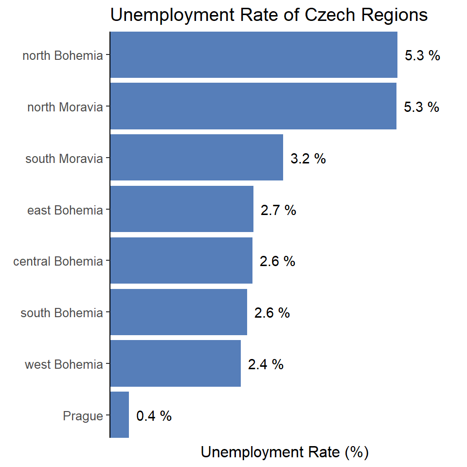

```r
plot <- ggplot(
  db_card %>%  group_by(region) %>% summarize(avg_unemp = mean(avg_unemployment)) %>% ungroup(),
       aes(x = reorder(region, avg_unemp), y = avg_unemp)) +
  geom_bar(alpha = 1, stat = 'identity', fill = '#567eb9') +
  scale_y_continuous(expand = c(0,0), limits = c(0, 6.5)) +
  scale_x_discrete(expand = c(0,0)) +
  labs(
    title = "Unemployment Rate of Czech Regions",
    x = element_blank(),
    y = "Unemployment Rate (%)"
  ) +
  coord_flip() +
  geom_text(aes(label=paste(round(avg_unemp,1), '%')), hjust = -0.2, color = 'black') +
  theme_classic() +
  theme(axis.text.x = element_blank(),
        axis.ticks.x = element_blank(),
        axis.line.x = element_blank(),
        text = element_text(size = 12) # text size
  )

ggsave("output/amounts.pdf", plot = plot, device = "pdf", width = 5, height = 5)
print(plot)
```

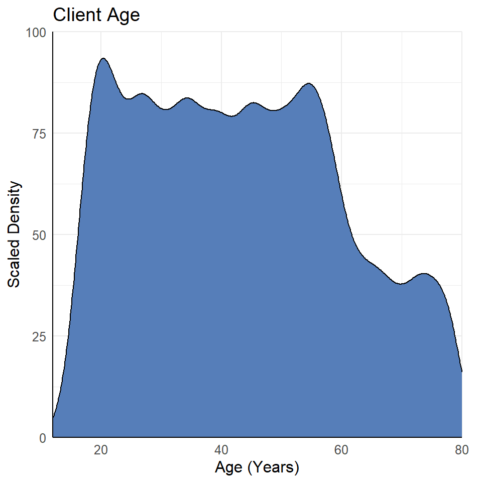

```r
plot <- ggplot(db_card, aes(x = age_card_purchase, y = ..count..)) +
  geom_density(bw = 2, alpha = 1, fill = '#567eb9') +
  scale_x_continuous(name = "Age (Years)", expand = c(0, 0)) +
  scale_y_continuous(limits = c(0, 100), expand = c(0, 0), name = "Scaled Density") +
  #guides(fill = guide_legend(override.aes = list(linetype = 0)))
  coord_cartesian(clip = "off") +
  theme_minimal() +
  theme(
    legend.position = "none",
    legend.justification = c("right", "top"),
    legend.box.background = element_rect(fill = "white", color = "white"),
    plot.margin = margin(7, 7, 3, 3),
    axis.line = element_line(colour = "black")
  ) +
  annotate("segment", x=-Inf, xend=Inf, y=-Inf, yend=-Inf)+
  annotate("segment", x=-Inf, xend=-Inf, y=-Inf, yend=Inf) +
  labs(
    title = "Client Age",
    fill = element_blank()
  ) +
  theme(
    text = element_text(size = 12), # text size
    plot.margin = margin(5, 15, 5, 5)# change plot margins
  )

ggsave("output/distributions.pdf", plot = plot, device = "pdf", width = 5, height = 5)
print(plot)
```

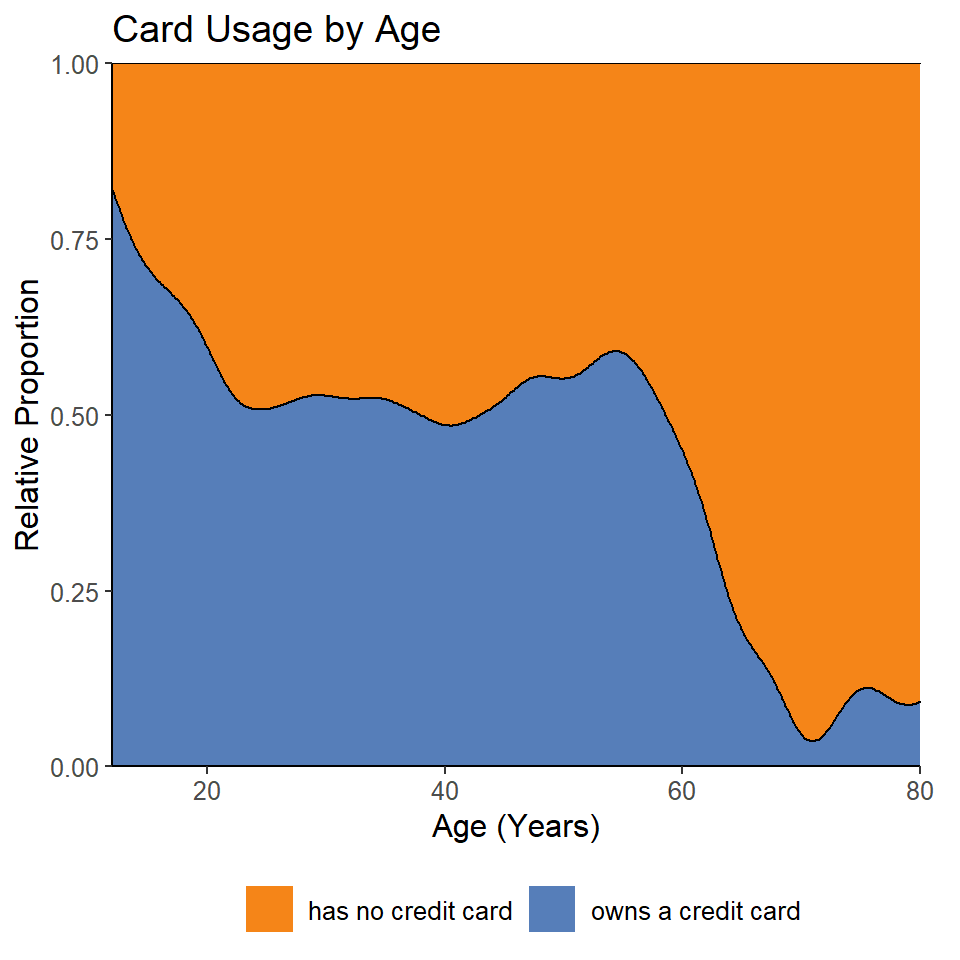

```r
plot1 <- ggplot(db_card, aes(x = age_card_purchase, fill = has_card)) +
  geom_density(position = "fill", alpha = 1, bw = 2) +
  scale_x_continuous(expand = c(0,0)) +
  scale_y_continuous(expand = c(0,0)) +
  labs(
    title = "Card Usage by Age",
    x = "Age (Years)",
    y = "Relative Proportion",
    fill = element_blank()
  ) +
  theme_classic() + # change theme
  scale_fill_manual(
    values = c("#f58518", "#567eb9"),
    labels = c('has no credit card', 'owns a credit card'),
    guide = guide_legend(override.aes = list(color = NA, size = 0))
  ) +
  theme(legend.position = 'bottom',
        text = element_text(size = 12), # text size
        plot.margin = margin(5, 15, 5, 5)) # change plot margins (border)

ggsave("output/proportions.pdf", plot = plot1, device = "pdf", width = 5, height = 5)
print(plot1)
```

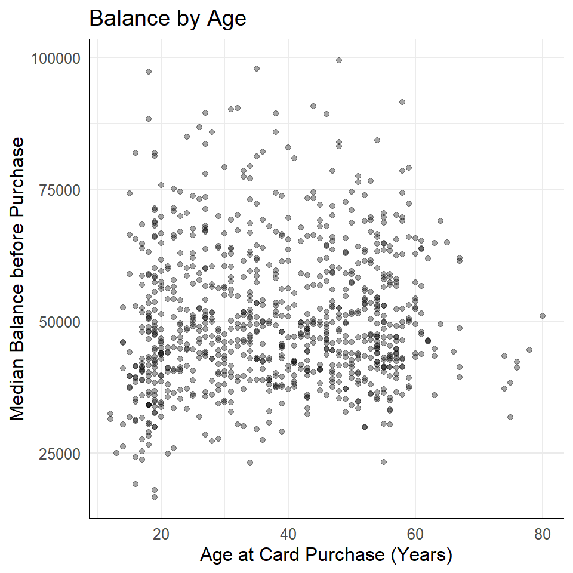

```r
plot <- ggplot(db_card %>% filter(has_card == "hat Kreditkarte"), aes(x = age_card_purchase, y = median_balance_before)) +
  geom_point(alpha = 0.35) +
  labs(
    title = "Balance by Age",
    x = "Age at Card Purchase (Years)",
    y = "Median Balance before Purchase",
    fill = "Nutzung"
  ) +
  theme_minimal() +
  annotate("segment", x=-Inf, xend=Inf, y=-Inf, yend=-Inf)+
  annotate("segment", x=-Inf, xend=-Inf, y=-Inf, yend=Inf) +
  theme(
    text = element_text(size = 12), # text size
  )


ggsave("output/relationships.pdf", plot = plot, device = "pdf", width = 5, height = 5)
print(plot)
```

```r
czech_regions <- st_read("cz.json")
```

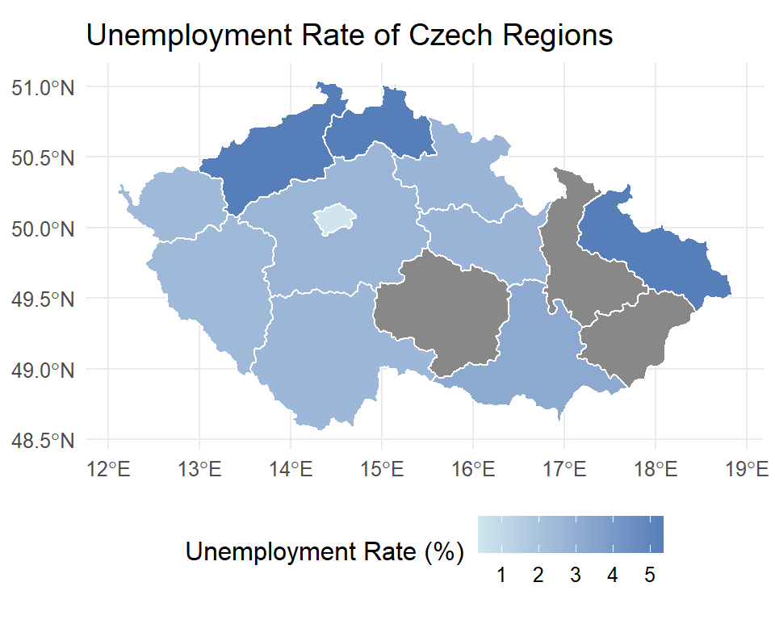

```r
db_card_agg <- db_card %>%  group_by(region) %>% summarize(avg_unemp = mean(avg_unemployment))

czech_map_data <- czech_regions %>%
  left_join(db_card_agg, by = c("name" = "region"))

plot <- ggplot(czech_map_data) +
  geom_sf(aes(fill = avg_unemp), color = "white") +
  scale_fill_gradient(low = "#cfe6ee", high = "#567eb9", na.value = "#888888") +
  labs(
    title = "Unemployment Rate of Czech Regions",
    fill = "Unemployment Rate (%)"
  ) +
  theme_minimal() +
  theme(legend.position = "bottom",
    text = element_text(size = 12), # text size
  )

ggsave("output/geospatial.pdf", plot = plot, device = "pdf", width = 5, height = 4)
print(plot)
```

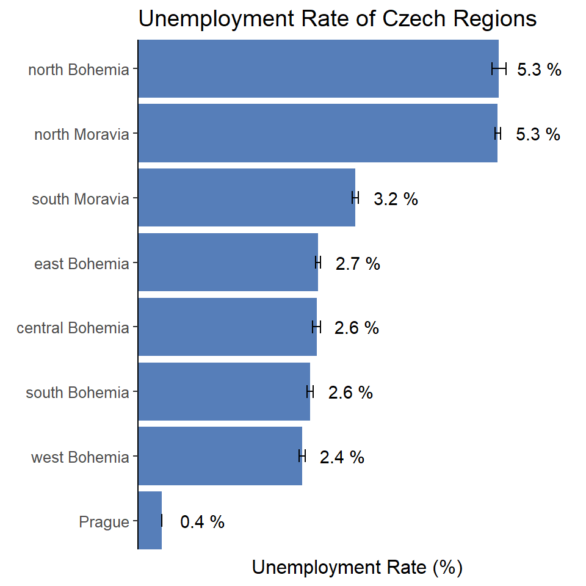

```r
data <- db_card %>%
  group_by(region) %>%
  summarize(
    avg_unemp = mean(avg_unemployment),
    se_unemp = sd(avg_unemployment) / sqrt(n())  # Standard error calculation
  ) %>%
  ungroup()

plot <- ggplot(data, aes(x = reorder(region, avg_unemp), y = avg_unemp)) +
  geom_bar(alpha = 1, stat = 'identity', fill = '#567eb9') +
  geom_errorbar(aes(ymin = avg_unemp - se_unemp, ymax = avg_unemp + se_unemp), width = 0.2) +  # Add error bars
  scale_y_continuous(expand = c(0,0), limits = c(0, 6.5)) +
  scale_x_discrete(expand = c(0,0)) +
  labs(
    title = "Unemployment Rate of Czech Regions",
    x = element_blank(),
    y = "Unemployment Rate (%)"
  ) +
  coord_flip() +
  geom_text(aes(label = paste(round(avg_unemp, 1), '%')), hjust = -0.4, color = 'black') +
  theme_classic() +
  theme(axis.text.x = element_blank(),
        axis.ticks.x = element_blank(),
        axis.line.x = element_blank(),
        text = element_text(size = 12) # text size
  )

ggsave("output/uncertainty.pdf", plot = plot, device = "pdf", width = 5, height = 5)
print(plot)
```

```r
# Create age categories
db_card <- db_card %>%
  mutate(age_category = case_when(
    age_card_purchase <= 17 ~ "up to 17",
    age_card_purchase >= 18 & age_card_purchase <= 39 ~ "18-39",
    age_card_purchase >= 40 & age_card_purchase <= 64 ~ "40-64",
    age_card_purchase >= 65 ~ "65 or older"
  ))

# Summarize the data
summary_data <- db_card %>%
  group_by(age_category, has_card) %>%
  summarise(count = n()) %>%
  ungroup() %>%
  group_by(age_category) %>%
  mutate(proportion = count / sum(count) * 100) %>%
  ungroup()
```

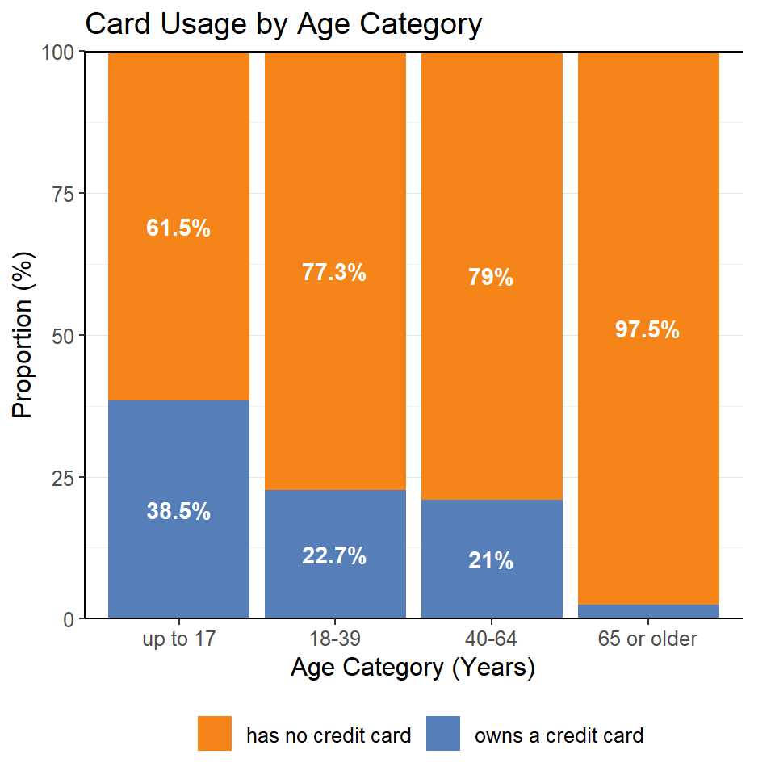

```r
# Ensure the age categories are in the desired order
summary_data$age_category <- factor(summary_data$age_category, levels = c("up to 17", "18-39", "40-64", "65 or older"))

# Plot the summarized data as a stacked bar chart with proportions
plot2 <- ggplot(summary_data, aes(x = age_category, y = proportion, fill = has_card)) +
  geom_bar(stat = "identity") +
  scale_y_continuous(expand = c(0,0)) +
  labs(
    title = "Card Usage by Age Category",
    x = "Age Category (Years)",
    y = "Proportion (%)",
    fill = element_blank()
  ) +
  theme_classic() +
  geom_hline(yintercept = 100, color = "black", size = 1) +  # black line at 100%
  geom_text(aes(label = ifelse(proportion > 5, paste0(round(proportion, 1), "%"), "")),
            position = position_stack(vjust = 0.5), color = "white", fontface = "bold") +
  scale_fill_manual(values = c("#f58518", "#567eb9"), labels = c('has no credit card', 'owns a credit card')) +
  theme(legend.position = 'bottom',
        text = element_text(size = 12),
        plot.margin = margin(5, 15, 5, 5),
    panel.grid.major = element_line(color = "grey90", size = 0.2),  # subtle major grid lines
    panel.grid.minor = element_line(color = "grey95", size = 0.1)   # subtle minor grid lines
  )
# Save the plot
ggsave("output/age_categories_proportions.pdf", plot = plot2, device = "pdf", width = 5, height = 5)

# Display the plot
print(plot2)
```

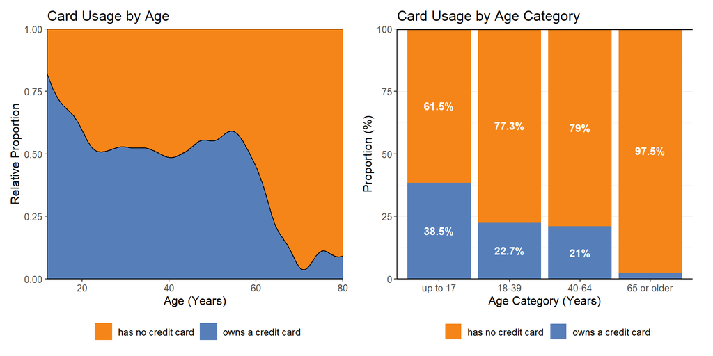

```r
combined_plot <- plot1 + plot2 + plot_layout(ncol = 2)
ggsave("output/categorize.pdf", plot = combined_plot, device = "pdf", width = 10, height = 5)
print(combined_plot)
```

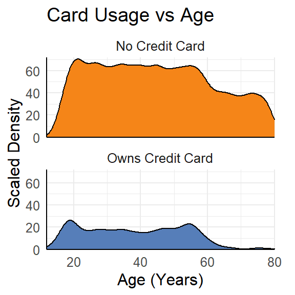

```r
plot <- ggplot(db_card, aes(x = age_card_purchase, y = ..count.., fill = has_card)) +
  geom_density(bw = 2, alpha = 1) +
  scale_x_continuous(name = "Age (Years)", expand = c(0, 0)) +
  scale_y_continuous(limits = c(0, 72), expand = c(0, 0), name = "Scaled Density") +
  #guides(fill = guide_legend(override.aes = list(linetype = 0)))
  coord_cartesian(clip = "off") +
  theme_minimal() +
  scale_fill_manual(values = c("hat keine Kreditkarte" = "#f58518", "hat Kreditkarte" = "#567eb9")) +
  theme(
    legend.position = "none",
    legend.justification = c("right", "top"),
    legend.box.background = element_rect(fill = "white", color = "white"),
    plot.margin = margin(7, 7, 3, 3),
    axis.line = element_line(colour = "black")
  ) +
  annotate("segment", x=-Inf, xend=Inf, y=-Inf, yend=-Inf)+
  annotate("segment", x=-Inf, xend=-Inf, y=-Inf, yend=Inf) +
  labs(
    title = "Card Usage vs Age",
    fill = element_blank()
  ) +
  theme(
    text = element_text(size = 12), # text size
    plot.margin = margin(5, 15, 5, 5)# change plot margins (border)
  ) +
  facet_wrap(~has_card, labeller = as_labeller(c('hat keine Kreditkarte' = 'No Credit Card', 'hat Kreditkarte' = 'Owns Credit Card')), dir = "v")

ggsave("output/facet.pdf", plot = plot, device = "pdf", width = 3, height = 3)
print(plot)
```

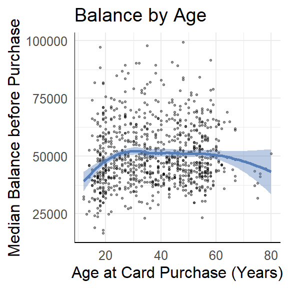

```r
plot <- ggplot(db_card %>% filter(has_card == "hat Kreditkarte"), aes(x = age_card_purchase, y = median_balance_before)) +
  geom_point(alpha = 0.4, size=0.5) +
  labs(
    title = "Balance by Age",
    x = "Age at Card Purchase (Years)",
    y = "Median Balance before Purchase",
    fill = "Nutzung"
  ) +
  stat_smooth(fill="#567eb9", color="#567eb9") +
  theme_minimal() +
  annotate("segment", x=-Inf, xend=Inf, y=-Inf, yend=-Inf)+
  annotate("segment", x=-Inf, xend=-Inf, y=-Inf, yend=Inf) +
  theme(
    text = element_text(size = 12), # text size
  )


ggsave("output/layers.pdf", plot = plot, device = "pdf", width = 3, height = 3)
print(plot)
```